# Evaluating Topic Models for Text

### Matti Lyra

### @mattilyra

### github.com/mattilyra/pydataberlin-2017

### mattilyra.github.io

### Overview of what's available

### Links to releveant literature and software

### Intuition as to what the evaluation measure(s) aim to capture

- open source tools
- open access research papers

## Eye Balling models

- top N words
- topics / documents

## Intrinsic Evaluation Metrics

- modelling corpus structure
- interpretability of topics

## Human Judgements

- what is a topic

## Extrinsic Evaluation / Evaluation at a Task

# Topic Models

- topic is semantically defined as co-occurrence patterns of words in context
  - tweet, sentence, paragraph, news article, book chapter
- document $\rightarrow$ topic decomposition
- models abound
  - Latent Dirichlet Allocation
  - Hierarchical Dirichlet Process
  - Spherical HDP
  - Latent Semantic Analysis / Latent Semantic Indexing
  - pLSA

### Why do you need to evaluate the model

- has it captured the internal structure of the corpus
- are the topic understandable
- are the topics coherent
- does it serve the purpose it is being used for
  - the use case defines a "*good*" model
  - often there is no objective *good*

[figure not shown]

# Top N Words from a Topic Model

|  |  | TOPICS 5 | TOPICS 6 | TOPICS 7 | TOPICS 8 | TOPICS 9 | TOPICS 10 | TOPICS 11 | TOPICS 12 |
| --- | --- | --- | --- | --- | --- | --- | --- | --- | --- |
| TOP 6 WORDS | 0 | russia | market | use | post | pipeline | child | water | clinton |
|  | 1 | russian | cancer | drug | comment | dakota | school | study | campaign |
|  | 2 | putin | product | health | facebook | police | police | health | hillary |
|  | 3 | nato | bank | company | news | water | family | toxic | email |
|  | 4 | missile | study | report | video | rock | when | flint | podesta |
|  | 5 | nuclear | report | medical | result | protester | people | tea | wikileaks |

# Eye Balling Models

- Chuang et. al *Termite: Visualization Techniques for Assessing Textual Topic Models*, AVI 2012
- Chuang et. al *Topic Model Diagnostics: Assessing Domain Relevance via Topical Alignment*, ICML 2013
- Sievert et. al *LDAVis: A method for visualizing and interpreting topics*, 2014

# Stanford VIS Group

[figure not shown]

Chuang et. al 2012

[figure not shown]

Chuang et. al 2013

# pyLDAVis

- Sievert et. al *LDAvis: A method for visualizing and interpreting topics* ACL 2014 (workshop)

https://github.com/bmabey/pyLDAvis

http://nbviewer.jupyter.org/github/bmabey/pyLDAvis/blob/master/notebooks/pyLDAvis_overview.ipynb

### Detailed Talk by Ben Mabey

https://www.youtube.com/watch?v=tGxW2BzC_DU

[figure not shown]

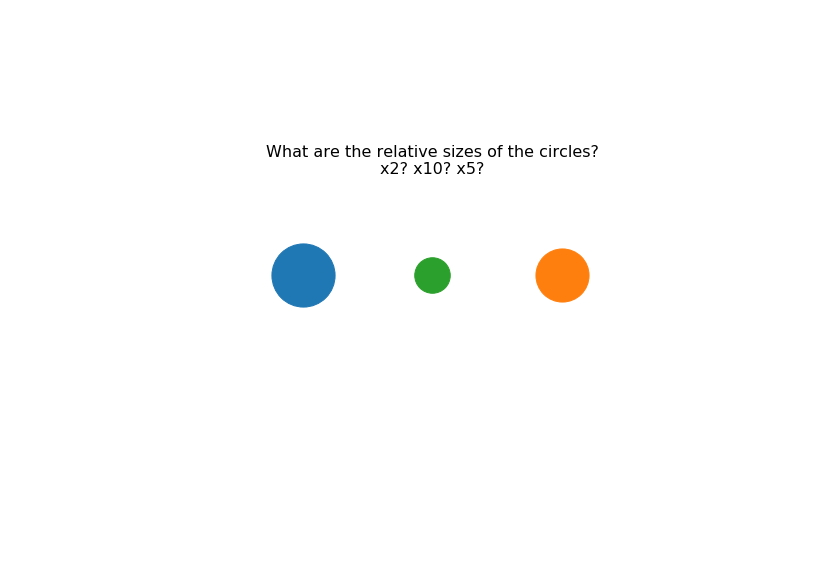

```python
plt.show()
```

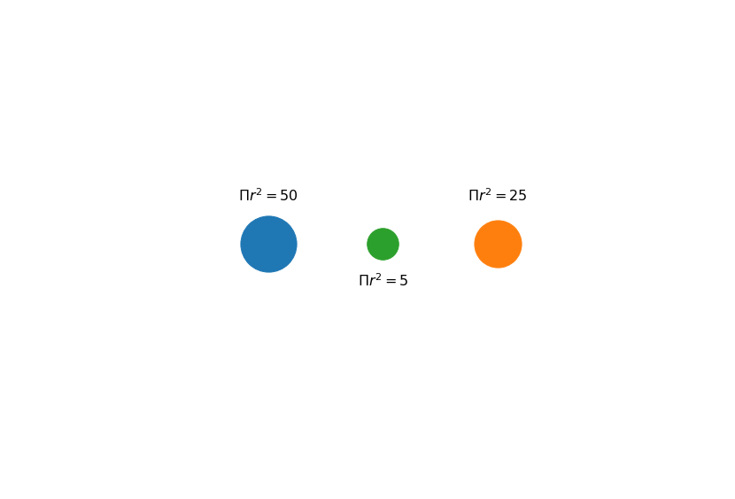

```python
plt.show()
```

[figure not shown]

# Intrinsic Evaluation

- Perplexity (is a bad measure)
- Chang et. al *Reading Tea Leaves: How Humans Interpret Topic Models* NIPS 2009

$$ \begin{align} H(D') &= \sum_{D'} P(w_d) \log_2 P(w_d)\\\\ PP &= 2^{H(D')} \end{align} $$

# Measure how Semantically Coherent a Model is

> ... began his professional career in 1989–90 with Jokerit of the SM-liiga and played 21 seasons in the National Hockey League (NHL) for the Winnipeg Jets ...

> Rinne stopped 27 of 28 shots from the Penguins in Game 6 at home Sunday, but that lone goal allowed was enough for the opposition to break out the Stanley Cup trophy for the second straight season.

# Measure how Semantically Coherent a Model is

> ... began his professional **career** in 1989–90 with **Jokerit** of the **SM-liiga** and **played** 21 **seasons** in the **National Hockey League** (**NHL**) for the **Winnipeg Jets** ...

> **Rinne** **stopped** 27 of 28 **shots** from the **Penguins** in **Game** 6 at home Sunday, but that lone **goal** allowed was enough for the **opposition** to break out the **Stanley Cup** **trophy** for the second straight **season**.

# Measure how Semantically Coherent a Model is

> career, Jokerit, SM-liiga, seasons, National Hockey League, NHL, Winnipeg Jets

> Rinne, stopped, shots, Penguins, Game, goal, opposition, Stanley Cup, trophy, season

$$ C_{UMass} = \frac{2}{N * (N-1)} \sum_{i-2}^{N} \sum_{j = 1}^{i-1} \log \frac{P(w_i, w_j)}{P(w_j)} $$

# Topic Coherence

- Newman et. al *Automatic Evaluation of topic coherence*, HLT 2010
- Mimno et.al *Optimizing semantic coherence in topic models* EMNLP 2011
- Aletras et. al *Evaluating topic coherence using distributional semantics* IWCS 2013
- Röder et. al *Exploring the Space of Topic Coherence Measures*, WSDM 2015

https://rare-technologies.com/what-is-topic-coherence/

[figure not shown]

# Topics

|  |  | TOPICS 5 | TOPICS 6 | TOPICS 7 | TOPICS 8 | TOPICS 9 | TOPICS 10 | TOPICS 11 | TOPICS 12 |
| --- | --- | --- | --- | --- | --- | --- | --- | --- | --- |
| TOP 6 WORDS | 0 | russia | market | use | post | pipeline | child | water | clinton |
|  | 1 | russian | cancer | drug | comment | dakota | school | study | campaign |
|  | 2 | putin | product | health | facebook | police | police | health | hillary |
|  | 3 | nato | bank | company | news | water | family | toxic | email |
|  | 4 | missile | study | report | video | rock | when | flint | podesta |
|  | 5 | nuclear | report | medical | result | protester | people | tea | wikileaks |

# Segmentation

|  |  | WORDS 0 | WORDS 1 | WORDS 2 | WORDS 3 | WORDS 4 | WORDS 5 |
| --- | --- | --- | --- | --- | --- | --- | --- |
| TOPIC | 9 | pipeline | dakota | police | water | rock | protester |

# Confirmation Measure

### Using a held out reference corpus compute

$$ C_{UMass} = \frac{2}{N * (N-1)} \sum_{i-2}^{N} \sum_{j = 1}^{i-1} \log \frac{P(w_i, w_j)}{P(w_j)} $$

# Probability Calculation

$$ \begin{align} \\ P(w_i, w_j) &= \frac{\mbox{Number of documents that contain words $w_i$ and $w_j$}}{\mbox{total number of documents}}\\ \\ P(w_i) &= \frac{\mbox{Number of documents that contain $w_i$}}{\mbox{total number of documents}}\\ \\ P(w_j) &= \frac{\mbox{Number of documents that contain $w_j$}}{\mbox{total number of documents}} \end{align} $$

$$ coherence(\Phi_{35}; segmentation, probability, C_V, aggregation) = 0.738 \;\;\; \in \left[-1, 1\right] \;\;\; \mbox{(I think!?)} $$

$$ coherence(\Phi_{35}; segmentation, probability, C_{UCI}, aggregation) = 0.511 \;\;\; \in \left[-\infty, \infty\right] $$

$$ coherence(\Phi_{100}; segmentation, probability, C_{UCI}, aggregation) = -0.840 \;\;\; \in \left[-\infty, \infty\right] $$

$$ coherence(\Phi_{35}; segmentation, probability, C_{UMass}, aggregation) = -1.653 \;\;\; \in \left[-\infty, \infty\right] $$

$$ \mbox{1. mean over a bunch of values with no estimate of variance} $$

$$ \mbox{2. different values are not comparable} $$

$$ \mbox{3. need to be very careful what the reference corpus is} $$

$$ \mbox{4. extra "junk" topics not accounted for} $$

# Human Judgement Based Methods

- Chang et. al *Reading Tea Leaves: How Humans Interpret Topic Models* NIPS 2009
- Lau et. al *Machine Reading Tea Leaves: Automatically Evaluating Topic Coherence and Topic Model Quality* EACL 2014

### Word Intrusion

`{dog, cat, horse, apple, pig, cow}`

`{cat, airport, yarn, horse, security, tomorrow}`

### Topic Intrusion

#### TRUMP SUPPORTER GOT NUTS On MSNBC Reporter Covering Anti-Trump Rioters [Video]

Go to Article A Trump supporter wearing a Trump/Pence t-shirt let it fly on a reporter from MSNBC because of his one sided reporting and the demonizing of Trump. This is one brave woman! New Yorkers have had enough ...

[figure not shown]

### Topic Intrusion

#### TRUMP SUPPORTER GOT NUTS On MSNBC Reporter Covering Anti-Trump Rioters [Video]

Go to Article A Trump supporter wearing a Trump/Pence t-shirt let it fly on a reporter from MSNBC because of his one sided reporting and the demonizing of Trump. This is one brave woman! New Yorkers have had enough ...

|  | 0 | 1 | 2 | 3 | 4 | 5 | 6 | 7 |
| --- | --- | --- | --- | --- | --- | --- | --- | --- |
| 33 | clinton | hillary | campaign | trump | foundation | bill | pay | president |
| 17 | god | church | people | abortion | christian | marriage | father | christians |
| 1 | syria | war | al | us | syrian | isis | terrorist | attack |

# Summary

- Topic models are difficult to evaluate
- qualitative evaluation is labour intensive and often subjective
- quantitative analysis relies on
  - intrinsic methods that do not always produce easy to understand results
  - inter-annotator agreement on what is understandable (datasets are expensive to produce)
  - sets of words that (hopefully) capture the semantics of a category
- open source software is available
- a universally "*good*" model does not exist!
  - all depends on what you want to do with the model

# What are Words?

[video not shown]

# What are Words?

> "What does he mean when he says words, does he mean the words or does he mean something like the words?"

{cat, dog, pet, rabbit, horse}

{cat, dog, pet, snowball, whiskers}

{cat (people), dog (people)}

# Evaluating of Topic Models

## Matti Lyra

## @mattilyra

## github.com/mattilyra

@mattilyra // github.com/mattilyra